# Joins and Pivots

POLS 6394 · Week 4 · Thursday, September 17

## Today

- Attach information from another table with `left_join()`
- Choose matching keys and check their uniqueness
- Find unmatched names and duplicated keys
- Reshape columns into rows and rows into columns
- Assemble a country comparison from two files

# Joining Tables

## Why combine tables?

A research project may have outcomes in one file, covariates in another, and region names in a lookup table.

A join matches rows using shared identifiers, called **keys**, and brings the corresponding columns together.

Sorting two tables and pasting columns beside each other assumes the rows line up. A join uses the identifiers to establish the match.

## Why log joins and pivots?

These operations can run without an R error while producing the wrong research result:

- Unmatched join keys can create `NA` values or drop rows.
- Repeated keys can multiply rows.
- A pivot can reorganize the wrong columns or produce an unexpected number of rows.

We load `tidylog` after the tidyverse so supported joins and pivots print a short report as they run. Read that report, then check the keys, row counts, and missing values yourself.

## The regional summary from 04a

We’ll first rebuild the one-row-per-region table from 04a.

```r
region_summary <- policy |>
  filter(!is.na(region.name)) |>
  group_by(region.name) |>
  summarize(
    region_mean = mean(pollib_median, na.rm = TRUE)
  )
region_summary
```

```
# A tibble: 4 × 2
  region.name region_mean
  <chr>             <dbl>
1 midwest          0.0107
2 northeast        1.33
3 south           -0.830
4 west             0.0932
```

This reproduces the regional means from last class using today’s supplied data. The filter removes observations without a recorded region. Each summary row represents one region; the source `policy` table has one row per state-year.

## Attach the regional mean

Now we’ll attach each regional mean to the matching state-year rows.

```r
policy_joined <- policy |>
  left_join(region_summary, by = "region.name")
```

```
left_join: added one column (region_mean)
           > rows only in policy            196
           > rows only in region_summary (    0)
           > matched rows                 2,009
           >                             =======
           > rows total                   2,205
```

```r
policy_joined |>
  select(st, year, region.name, pollib_median, region_mean)
```

```
select: dropped 21 variables (state, pid, ideo, statemin, region, …)
```

```
# A tibble: 2,205 × 5
   st     year region.name pollib_median region_mean
   <chr> <dbl> <chr>               <dbl>       <dbl>
 1 AL     1976 south                -1.4      -0.830
 2 AL     1977 south                -1.4      -0.830
 3 AL     1978 south                -1.5      -0.830
 4 AL     1979 south                -1.5      -0.830
 5 AL     1980 south                -1.7      -0.830
 6 AL     1981 south                -1.7      -0.830
 7 AL     1982 south                -1.8      -0.830
 8 AL     1983 south                -1.8      -0.830
 9 AL     1984 south                -1.8      -0.830
10 AL     1985 south                -1.8      -0.830
# ℹ 2,195 more rows
```

The pipe supplies the left table, `policy`. `region_summary` is the right table. `by` names the shared key. Every state-year with a recorded region receives its matching region’s mean. Because `tidylog` is loaded, `left_join()` logs matched and unmatched rows and the columns added.

When a left-table row has no match, `left_join()` keeps the row and fills the new right-table columns with `NA`. R won’t stop or complain.

## Your Turn: use the attached value

*~3 minutes.*

Calculate how far each state’s policy score is above or below its regional mean, then inspect 2010.

```r
policy_joined |>
  mutate(difference = pollib_median - ___) |>
  filter(year == 2010) |>
  select(state, region.name, difference) |>
  arrange(desc(difference))
```

Compare the result with 04a’s grouped `mutate()`. For now we’re checking the mechanics; later we’ll join a file from a separate source.

## Which side needs unique keys?

Before trusting the join, check the lookup keys and confirm that the row count stayed the same.

```r
region_summary |>
  count(region.name) |>
  filter(n > 1)
```

```
# A tibble: 0 × 2
# ℹ 2 variables: region.name <chr>, n <int>
```

```r
nrow(policy)
```

```
[1] 2205
```

```r
nrow(policy_joined)
```

```
[1] 2205
```

Many state-years can share a region. The lookup needs one row per region for this many-to-one match. The duplicate check should return no rows, and the join should keep the original row count.

## Three ways to keep rows

Suppose the left table contains IDs A and B, while the right table contains B and C.

| Function | IDs retained |
| --- | --- |
| `left_join()` | A and B |
| `inner_join()` | B |
| `full_join()` | A, B, and C |

```r
main_ids <- tibble(id = c("A", "B"))
lookup_ids <- tibble(id = c("B", "C"), score = c(8, 9))

left_join(main_ids, lookup_ids, by = "id")
inner_join(main_ids, lookup_ids, by = "id")
full_join(main_ids, lookup_ids, by = "id")
```

`left_join()` is the usual choice when the left table defines the observations you plan to analyze. Use `full_join()` while comparing sources because it shows keys found on only one side. Use `inner_join()` only when unmatched observations really are outside the analysis.

## When non-key names conflict

These two sources both use `score` for different measurements.

```r
survey_scores <- tibble(id = c("A", "B"), score = c(6, 8))
benchmark_scores <- tibble(id = c("A", "B"), score = c(7, 9))

left_join(survey_scores, benchmark_scores, by = "id")
```

When both tables contain `score`, the result contains `score.x` from the left table and `score.y` from the right table. These automatic names are easy to confuse later.

```r
benchmark_scores <- benchmark_scores |>
  rename(benchmark_score = score)
left_join(survey_scores, benchmark_scores, by = "id")
```

Rename before joining when the columns have different meanings. Another option is `suffix = c("_survey", "_benchmark")`.

# Checking Matches

## Keep mismatches visible with full_join

We’ll mark each source, then combine a small lookup with the policy keys so names found on only one side remain visible.

```r
lookup <- tibble(
  st = c("TX", "Calif.", "NY"),
  program = c("Pilot", "Expanded", "Pilot")
) |>
  mutate(in_lookup = TRUE)
```

```
mutate: new variable 'in_lookup' (logical) with one unique value and 0% NA
```

```r
policy_keys <- policy |>
  distinct(st) |>
  mutate(in_policy = TRUE)
```

```
distinct: removed 2,156 rows (98%), 49 rows remaining
mutate: new variable 'in_policy' (logical) with one unique value and 0% NA
```

```r
reconciliation <- full_join(lookup, policy_keys, by = "st")
```

```
full_join: added one column (in_policy)
           > rows only in lookup        1
           > rows only in policy_keys  47
           > matched rows               2
           >                          ====
           > rows total                50
```

```r
reconciliation |> filter(is.na(in_policy))
```

```
filter: removed 49 rows (98%), one row remaining
```

```
# A tibble: 1 × 4
  st     program  in_lookup in_policy
  <chr>  <chr>    <lgl>     <lgl>
1 Calif. Expanded TRUE      NA
```

The source flags record where each row originated. Missing `in_policy` identifies `Calif.` as a lookup value with no policy match. Policy-only rows remain visible too. For a one-sided shortcut, `lookup |> anti_join(policy_keys, by = "st")` returns the same bad lookup key without retaining the full reconciliation.

## Measure missingness after the join

After joining, summarize the missingness in each column before inspecting individual records.

```r
reconciliation |>
  miss_var_summary()
```

```
# A tibble: 4 × 3
  variable  n_miss pct_miss
  <chr>      <int>    <num>
1 program       47       94
2 in_lookup     47       94
3 in_policy      1        2
4 st             0        0
```

`n_miss` counts missing values and `pct_miss` reports their percentage within each column. Here, missing `in_policy` identifies the failed `Calif.` match. Missing lookup fields for other states are expected because the teaching lookup contains only three entries.

The missingness summary tells us the scale. We still need the source flags and keys to see which records failed and why.

## Duplicate keys multiply rows

This lookup gives Texas two matches so we can see what duplication does to the result.

```r
dupe_lookup <- tibble(
  st = c("TX", "TX"),
  program = c("Pilot", "Expanded")
)
policy |>
  filter(st == "TX", year == 2010) |>
  left_join(dupe_lookup, by = "st") |>
  select(st, year, program)
```

```
# A tibble: 2 × 3
  st     year program
  <chr> <dbl> <chr>
1 TX     2010 Pilot
2 TX     2010 Expanded
```

One Texas observation becomes two rows. A join can succeed while changing the number of observations. Check the key and the row count.

## A check that stops the join

Once we know the lookup should have one row per region, we can make `left_join()` enforce that rule.

```r
policy_joined <- policy |>
  left_join(
    region_summary,
    by = "region.name",
    relationship = "many-to-one"
  )
```

`relationship = "many-to-one"` requires each left row to match at most one right row. Duplicate matches cause an error.

The default `left_join()` is convenient while exploring: it permits ordinary matches and warns about an unexpected many-to-many relationship. Here we know that `region_summary` should have one row per region, so the stricter check stops the pipeline before a duplicate region multiplies state rows and changes later summaries.

The tradeoff is that a real change in the data structure also stops the pipeline. Use this check when you know the intended relationship. It doesn’t require every row to match; check unmatched keys separately.

## State and year together

We’ll split the policy data into two practice tables that must be matched by both state and year.

```r
outcomes <- policy |> select(st, year, pollib_median)
covariates <- policy |>
  select(state_code = st, year, pid, statemin)

covariates |>
  count(state_code, year) |>
  filter(n > 1)
```

```
# A tibble: 0 × 3
# ℹ 3 variables: state_code <chr>, year <dbl>, n <int>
```

These practice tables split the supplied file into outcomes and covariates. In research they might arrive separately.

A state repeats across years. `st` and `year` together identify the observation.

## A join with two keys

Now we’ll attach covariates from the same state and the same year.

```r
analysis <- outcomes |>
  left_join(
    covariates,
    by = c("st" = "state_code", "year")
  )
analysis
```

```
# A tibble: 2,205 × 5
   st     year pollib_median   pid statemin
   <chr> <dbl>         <dbl> <dbl>    <dbl>
 1 AL     1976          -1.4  0.23    NA
 2 AL     1977          -1.4  0.25    NA
 3 AL     1978          -1.5  0.44    NA
 4 AL     1979          -1.5  0.38    NA
 5 AL     1980          -1.7  0.38     3.1
 6 AL     1981          -1.7  0.25     3.35
 7 AL     1982          -1.8  0.29     3.35
 8 AL     1983          -1.8  0.29     3.35
 9 AL     1984          -1.8  0.18     3.35
10 AL     1985          -1.8 -0.06     3.35
# ℹ 2,195 more rows
```

The names on the left of `=` belong to `outcomes`; the names on the right belong to `covariates`. Both the state and year values must match. When a key has the same name in both tables, writing `"year"` alone is sufficient.

Joining only on `st` would pair a state’s outcome in each year with its covariates in every year.

# Reshaping

## Wide and long data

**Wide data** places repeated measurements for one observation across several columns. **Long data** places those measurements down rows, with one column identifying the measurement and another holding its value.

The democracy table is wide: each country has one row and each measurement year has its own column.

```r
dem_score |>
  filter(country == "Guatemala")
```

```
# A tibble: 1 × 10
  country   `1952` `1957` `1962` `1967` `1972` `1977` `1982` `1987` `1992`
  <chr>      <dbl>  <dbl>  <dbl>  <dbl>  <dbl>  <dbl>  <dbl>  <dbl>  <dbl>
1 Guatemala      2     -6     -5      3      1     -3     -7      3      3
```

In a long version, each row would represent one country-year, with separate `year` and `democracy_score` columns.

## Tidy data describes structure

A dataset is tidy when:

1. Each variable has its own column.
2. Each observation has its own row.
3. Each value has its own cell.

For these data, **year** is a variable. The wide table stores its values in headings such as `1952` and `1957`; the long table gives year its own column.

Both shapes contain the same country-year scores. A pivot changes where those scores are stored.

## Strengths and weaknesses

|  | Wide data | Long data |
| --- | --- | --- |
| Easier for | Reading and side-by-side comparisons | Filtering, grouping, and plotting |
| New measurements | Often require new columns and revised code | Add rows; the same code often works |
| Main cost | A variable may be split across headings | Identifiers repeat and the table is less compact |

A wide table can still be analyzed and plotted. Long data usually makes tidyverse code shorter and easier to reuse. For a trend plot, wide data requires referring to the year columns separately; long data maps `year` and `democracy_score` once.

## Columns become rows

We’ll turn Guatemala’s year columns into one `year` variable and one `democracy_score` variable.

```r
guatemala <- dem_score |>
  filter(country == "Guatemala") |>
  pivot_longer(
    cols = -country,
    names_to = "year",
    values_to = "democracy_score"
  ) |>
  mutate(year = as.integer(year))
```

```
filter: removed 95 rows (99%), one row remaining
pivot_longer: reorganized (1952, 1957, 1962, 1967, 1972, …) into (year, democracy_score) [was 1x10, now 9x3]
mutate: converted 'year' from character to integer (0 new NA)
```

```r
guatemala
```

```
# A tibble: 9 × 3
  country    year democracy_score
  <chr>     <int>           <dbl>
1 Guatemala  1952               2
2 Guatemala  1957              -6
3 Guatemala  1962              -5
4 Guatemala  1967               3
5 Guatemala  1972               1
6 Guatemala  1977              -3
7 Guatemala  1982              -7
8 Guatemala  1987               3
9 Guatemala  1992               3
```

`cols = -country` pivots every column except `country`. `names_to` holds the former headings; `values_to` holds their values. `as.integer()` converts year labels into numbers. The `tidylog` message reports the table’s dimensions before and after the pivot; an unexpected size can reveal a mistaken column selection.

## A small before-and-after view

These are the first three years for Guatemala from the supplied file.

**Before: one country row**

| country | 1952 | 1957 | 1962 |
| --- | --- | --- | --- |
| Guatemala | 2 | -6 | -5 |

**After: one country-year per row**

| country | year | democracy_score |
| --- | --- | --- |
| Guatemala | 1952 | 2 |
| Guatemala | 1957 | -6 |
| Guatemala | 1962 | -5 |

The year headings become values in `year`; the scores keep their country and year.

## The reshaped data can be plotted

With `year` in one column, one plot command uses every year.

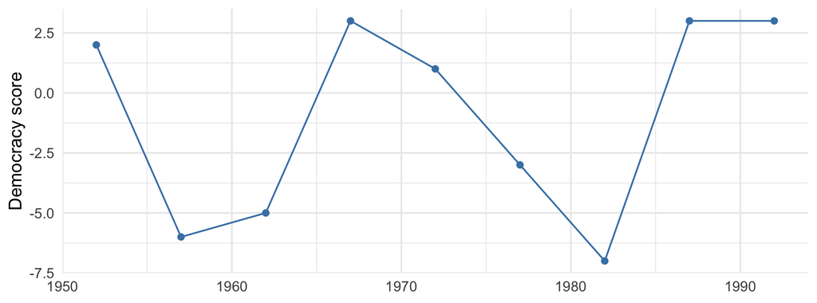

I’ve supplied the plot; we’ll learn its syntax next week. It works cleanly because `year` is a variable.

## Rows become columns

Wide data is handy when values need to sit side by side, such as subtracting one year from another, and for some presentation tables. We’ll usually return to long data for filtering, grouping, and plotting.

```r
guatemala_short <- guatemala |>
  filter(year %in% c(1952, 1962, 1972))
```

```
filter: removed 6 rows (67%), 3 rows remaining
```

```r
guatemala_wide <- guatemala_short |>
  pivot_wider(
    names_from = year,
    values_from = democracy_score,
    names_prefix = "score_"
  )
```

```
pivot_wider: reorganized (year, democracy_score) into (score_1952, score_1962,
score_1972) [was 3x3, now 1x4]
```

```r
guatemala_wide
```

```
# A tibble: 1 × 4
  country   score_1952 score_1962 score_1972
  <chr>          <dbl>      <dbl>      <dbl>
1 Guatemala          2         -5          1
```

`names_from` uses the year values as column headings. `values_from` supplies the democracy scores. The remaining `country` column identifies the row.

## The same values in wider form

**Before: one row per country-year**

| country | year | democracy_score |
| --- | --- | --- |
| Guatemala | 1952 | 2 |
| Guatemala | 1962 | -5 |
| Guatemala | 1972 | 1 |

**After: one row for the country**

| country | score_1952 | score_1962 | score_1972 |
| --- | --- | --- | --- |
| Guatemala | 2 | -5 | 1 |

The year values become column headings. The democracy scores remain attached to Guatemala and their respective years.

## Check keys before widening

Before widening, verify that each intended output cell has only one value.

```r
guatemala |> count(country, year) |> filter(n > 1)
```

```
# A tibble: 0 × 3
# ℹ 3 variables: country <chr>, year <int>, n <int>
```

For one score per country-year, this check should return no rows. If a country-year occurs twice, widening would have two scores for the same cell.

Inspect repeated observations first. Decide whether they are duplicates, need another identifier, or should be summarized before pivoting.

## Your Turn: compare two years

*~5 minutes.*

The workbook supplies the summary below. Spread the two years into columns.

```r
life_summary |>
  pivot_wider(
    names_from = ___,
    values_from = median_life,
    names_prefix = "life_"
  ) |>
  mutate(gain = life_2007 - life_1952)
```

`names_prefix = "life_"` makes names such as `life_1952`. The subtraction then calculates the change along each continent’s row.

# Lab

## Lab: OECD membership and outcomes

*~25 minutes, including ordinary troubleshooting.*

Use `Data/gapminder/gapminder.csv` and `Labs/w04/oecd_membership.csv`.

The supplied membership lookup covers selected OECD countries in the Gapminder sample. Treat membership in this exercise as membership in that supplied list, not a complete classification of every country’s OECD status.

Check the names before comparing the listed countries with the remaining sample.

## Lab: three tasks

1. Reconcile both sets of country names, repair the mismatches, and attach membership to the 2007 observations.
2. Run the supplied comparison of the two groups and interpret it.
3. Reshape three countries’ democracy scores from year columns into year rows and check the result.

Commit and push before leaving, even if unfinished. When you finish at home, render, commit, and push again.

## Finalize 04b

If you finish at home, render the completed workbook, make a final commit, and push.

- Save and render the workbook. Keep unfinished chunks at `eval: false`.
- Inspect your changes, commit, and push before leaving, even if unfinished.
- Confirm the commit appears on GitHub. If rendering fails, record the error and still push the saved QMD.

## Before Next Class

- **Problem Set 1:** complete `Psets/pset-01/pset-01.qmd`. Extend the democracy reshape across all countries and validate the result. Due **10:00 AM Thursday, September 24**.
- **Next class:** strings, dates, and factors.
- **Read:** ModernDive chapter 4. Heiss’s [reshaping primer](https://r-primers.andrewheiss.com/tidy-data/01-reshape-data/) offers optional practice.

# If Time Remains: Additional Teaching

These examples are optional teaching material. They are not extra-credit tasks.

## Additional example: repair a broken merge

*~8–12 minutes.*

This teaching lookup has both a mismatched name and a repeated key.

```r
programs <- tibble(
  state_code = c("TX", "Calif.", "NY", "NY"),
  coverage = c(20, 35, 40, 40)
)
programs
```

```
# A tibble: 4 × 2
  state_code coverage
  <chr>         <dbl>
1 TX               20
2 Calif.           35
3 NY               40
4 NY               40
```

Use `anti_join()` to find the mismatch. Use `count()` to find the repeated key. The two NY rows are accidental copies in this example.

## The keys have different names

`anti_join()` can compare the keys even when their columns have different names.

```r
programs |>
  anti_join(policy, by = c("state_code" = "st"))
```

```
# A tibble: 1 × 2
  state_code coverage
  <chr>         <dbl>
1 Calif.           35
```

`by = c("state_code" = "st")` matches the left key’s name to the right key’s name.

Repair `Calif.` with the `case_when()` form from the lab. `distinct()` with no arguments removes identical rows; use it only after confirming these are accidental copies.

## Verify the repair

Join the corrected lookup onto 2010 policy observations:

```r
program_check <- policy |>
  filter(year == 2010) |>
  left_join(
    programs_fixed,
    by = c("st" = "state_code"),
    relationship = "many-to-one"
  )
nrow(program_check)
program_check |>
  filter(!is.na(coverage)) |>
  select(st, coverage)
```

`nrow()` checks the row count. The final pipeline shows which states received coverage values. The lookup covers only three states, so the others remain missing.

If repeated keys have conflicting values, determine which record belongs in the analysis before removing anything.

# Optional Take-Home Extra Credit

## Join, summarize, and reshape

Worth up to **one point beyond the regular three-point lab score**. This is take-home work; it is not part of the in-class lab.

Build a two-year table comparing the countries in the supplied membership list with the remaining Gapminder countries.

1. Keep 1952 and 2007.
2. Join the repaired lookup from Task 1 by country.
3. Label membership using the supplied list, then summarize life expectancy by group and year.
4. Pivot the summary wider and calculate each group’s change in median life expectancy.
5. State which group gained more years and report both gains.

This classifies both years using the same list. It does not measure membership as of 1952.

Write the complete pipeline in the workbook. Render, commit, and push it with your interpretation.